# Landsberg Model

Hao-Ran Wu ( haoranwu @ zju.edu.cn )

2022-09-16

In this section we are concerned about how to fit Landsberg model through the function `photo.landsberg.fit()`.

## Code Example(s)

```r
# Fit Landsberg Model
# ********************************
#
# Fit Landsberg model (Landsberg, 1977) from measured photosynthesis rate and
# photosynthetically active radiation.
#
# ********************************
# List of variables and units for this example
#
# 'path'        path of a CSV file, which contains two columns (with table titles)
#                * column 1: photosynthetically active radiation (μmol m-2 s-1)
#                * column 2: photosynthesis rate (μmol m-2 s-1)
#
# ********************************
# Step 1: import package
require(bproce)

# Step 2: choose parameters
path  <- "./data/2-2B Simulated Photosynthesis Rate for Landsberg Model.csv"

# Step 3: read data
dat   <- read.csv(path)   # read the CSV file
                          #  * column 1 ($PAR): photosynthetically active radiation
                          #  * column 2 ($Pn): measured photosynthesis rate

# Step 4: fit the model
md <- photo.landsberg.fit(dat$PAR, dat$Pn)

fitted_alpha  <- md$coef[["alpha"]]   # extract fitted model paramters
fitted_Pm     <- md$coef[["Pm"]]
fitted_Icomp  <- md$coef[["Icomp"]]

cat(
  paste("***** Fit Landsberg Model *****\n"),
  paste("alpha = ", fitted_alpha, "\n"),
  paste("Pm = ", fitted_Pm, "(μmol m-2 s-1)\n"),
  paste("Icomp = ", fitted_Icomp, "(μmol m-2 s-1)\n"),
  paste("Multiple R-squared:", md$r.square,"\n"),
  paste("Adjusted R-squared:", md$adj.r.square,"\n")
)

# Step 5: model prediction
predicted_Pm <- photo.landsberg(dat$PAR, alpha = fitted_alpha, Pm = fitted_Pm,
                                Icomp = fitted_Icomp)
                      # calculate photosynthesis rate based on the fitted model

plot(
  dat$PAR, dat$Pn,
  xlab = "Photosynthetically active radiation",
  ylab = "Photosynthesis rate",
  main = "Fit Landsberg Model"
)                             # plot measured photosynthesis rate versus PAR
lines(dat$PAR, predicted_Pm)  # plot fitted light response curve
```

## Explanation

**Step1:** Load the package `bproce` through the `require()` function.

```r
require(bproce)
```

**Step2:** Choose model parameters.

- `path`: the path of a CSV file which the data are to be read from. Each row of the file appears as one line, and columns are separated by commas (,). The first row appears as the table title. There should be two columns in this file:
  - Column 1: photosynthetically active radiation (µmol m<sup>−2</sup> s<sup>−1</sup>).
  - Column 2: measured photosynthesis rate (µmol m<sup>−2</sup> s<sup>−1</sup>).

```r
path  <- "./data/2-2B Simulated Photosynthesis Rate for Landsberg Model.csv"
```

**Step3:** Read data. Read the CSV file in table format and creates a data frame through the function `read.csv()`.

```r
dat <- read.csv(path)
print(head(dat), digits = 3)    #print first parts of the data
```

```
  PAR    Pn
1   0 -38.2
2  10 -36.4
3  20 -33.1
4  30 -28.5
5  40 -24.6
6  50 -22.0
```

where $P_m$ (µmol m<sup>−2</sup> s<sup>−1</sup>) is the maximum photosynthesis, *α* is the slope of the change in $P_n$ (µmol m<sup>−2</sup> s<sup>−1</sup>) with $PAR$ (i.e., a shape factor), and $I_{comp}$ (µmol m<sup>−2</sup> s<sup>−1</sup>) is the light compensation point at which $P_n$ is zero. To fit this model, use the function `photo.landsberg.fit()`.

```r
md <- photo.landsberg.fit(dat$PAR, dat$Pn)
```

The arguments and their meaning of the function `photo.landsberg.fit()` are shown in the table below:

[output not shown]

Now we can take a look at the fitted values of model parameters.

```r
fitted_alpha  <- md$coef[["alpha"]]   # extract fitted model paramters
fitted_Pm     <- md$coef[["Pm"]]
fitted_Icomp  <- md$coef[["Icomp"]]

cat(
  paste("***** Fit Landsberg Model *****\n"),
  paste("alpha = ", fitted_alpha, "\n"),
  paste("Pm = ", fitted_Pm, "(μmol m-2 s-1)\n"),
  paste("Icomp = ", fitted_Icomp, "(μmol m-2 s-1)\n"),
  paste("Multiple R-squared:", md$r.square,"\n"),
  paste("Adjusted R-squared:", md$adj.r.square,"\n")
)
```

```
***** Fit Landsberg Model *****
 alpha =  0.0105817884498688
 Pm =  7.69868831673845 (μmol m-2 s-1)
 Icomp =  188.889167296791 (μmol m-2 s-1)
 Multiple R-squared: 0.955504366714863
 Adjusted R-squared: 0.954333428996833
```

**Step 5:** Model prediction. Predict $P_n$ using the fitted model:

```r
predicted_Pm <- photo.landsberg(dat$PAR, alpha = fitted_alpha, Pm = fitted_Pm,
                                Icomp = fitted_Icomp)
```

Create a plot of $P_n$ against $PAR$ to compare observed and predicted values:

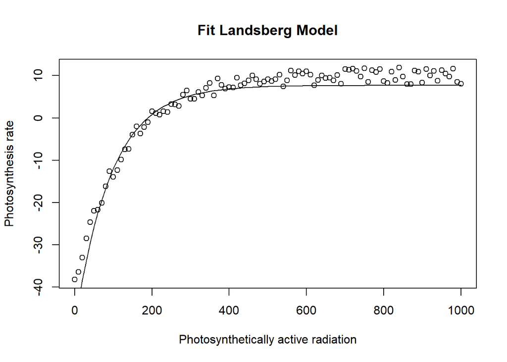

```r
plot(
  dat$PAR, dat$Pn,
  xlab = "Photosynthetically active radiation",
  ylab = "Photosynthesis rate",
  main = "Fit Landsberg Model"
)                             # plot measured photosynthesis rate versus PAR
lines(dat$PAR, predicted_Pm)  # plot fitted light response curve
```

The dots appear on the plot represent the observed values, whilst the solid curve represents the fitted light response curve.

## Reference

Landsberg, J. J. (1977). Some useful equations for biological studies. Experimental Agriculture, 13(3), 273–286.